# Business Data Analytics

## Visualization

Let’s try to practice how to do charts for our later analysis, as we will do a lot of graphs along the course. It is important to remember what is the purpose of your plots. There are plots with the main goal to communicate the message for the decision-makers or consumers. These plots have to clearly convey the message that was found and investigated earlier. For the exploratory analysis the graphs facilitate the discovery. We have to learn how to detect interesting and unexpected patterns and what questions to ask next.

### Bar chart. Multi-set bar chart

The following chart displays how many transactions per country were made.

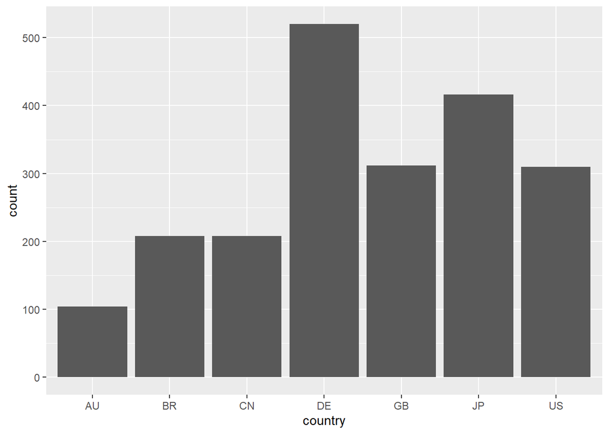

```r
ggplot(data = df) +
 geom_bar(mapping = aes(x = country))
```

Compare it to the results of the table df %>% count(country):

```r
df %>% count(country)
```

```
## # A tibble: 7 x 2
##   country     n
##   <fct>   <int>
## 1 AU        104
## 2 BR        208
## 3 CN        208
## 4 DE        520
## 5 GB        312
## 6 JP        416
## 7 US        310
```

The ggplot2 plots are very flexible. Let’s try to beautify it a bit:

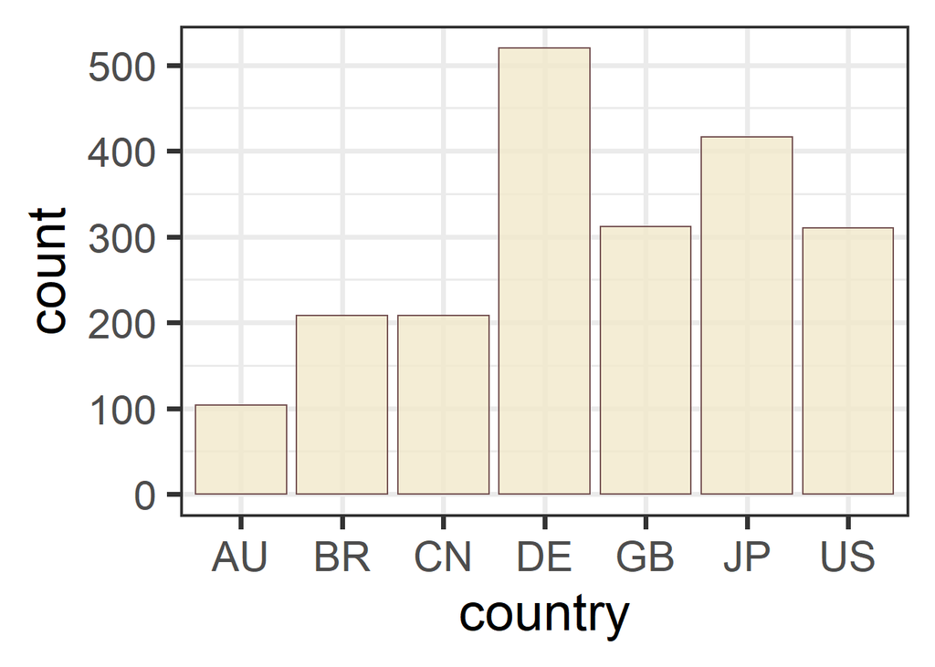

```r
ggplot(data = df) +
 geom_bar(mapping = aes(x = country), fill='#f1e8ca',
color='#745151', alpha=0.8) + theme_bw(base_size=28)
```

Multi-chart bar:

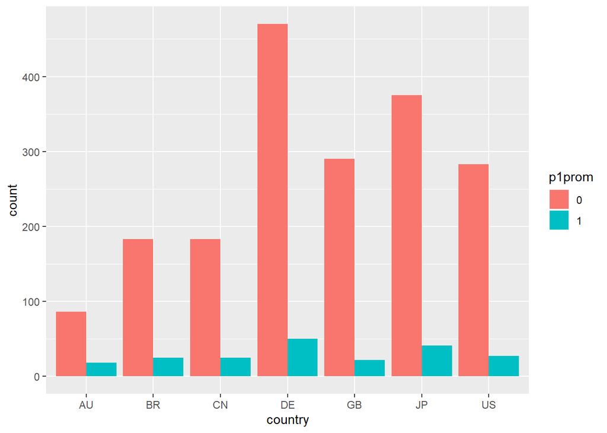

```r
df %>%
 mutate(p1prom = as.factor(p1prom)) %>%
 ggplot() +
 geom_bar(mapping = aes(x = country, fill=p1prom),
position='dodge')
```

How do you interpret this plot? Try to customize it by changing colors (check help for scale_fill_manual())

### Histogram. Density

Histogram shows the distribution of continuous variable. In a histogram the x-axis is partitioned into equal bins. The height of a bar shows how many observations fall into each bin. The results of the histogram heavily depend on the chosen bin size.

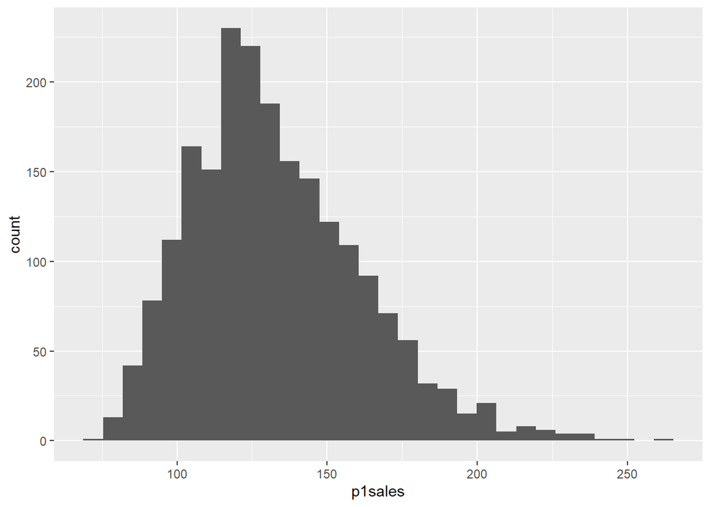

```r
ggplot(data = df) +
  geom_histogram(mapping = aes(x = p1sales))
```

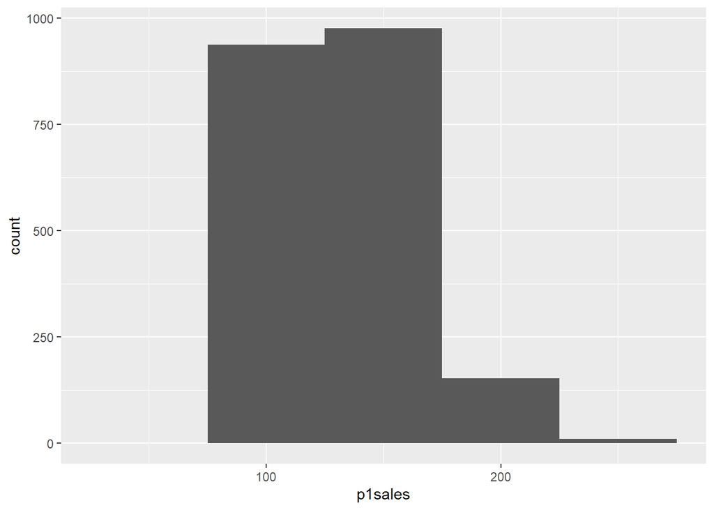

```r
ggplot(data = df) +
  geom_histogram(mapping = aes(x = p1sales), binwidth=50)
```

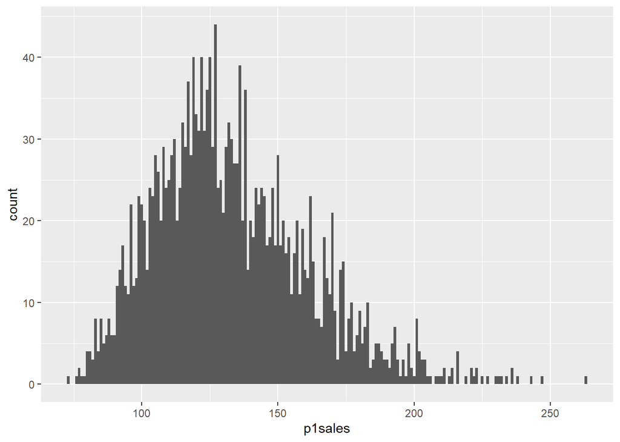

```r
ggplot(data = df) +
  geom_histogram(mapping = aes(x = p1sales), binwidth=1)
```

Another plot for the distribution is density plot. It is a smoothed histogram that provide a general estimate of the distribution. The area under the distribution is always sums to 1. It helps to estimate general tendency, however it comes at a cost, as y-axis is difficult to interpret.

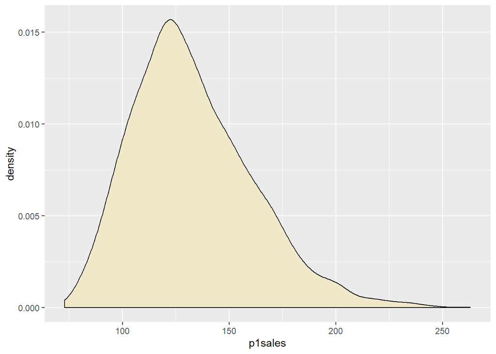

```r
ggplot(data = df) +
 geom_density(mapping = aes(x = p1sales), fill='#f1e8ca')
```

It is more helpful to compare several distributions via density plots:

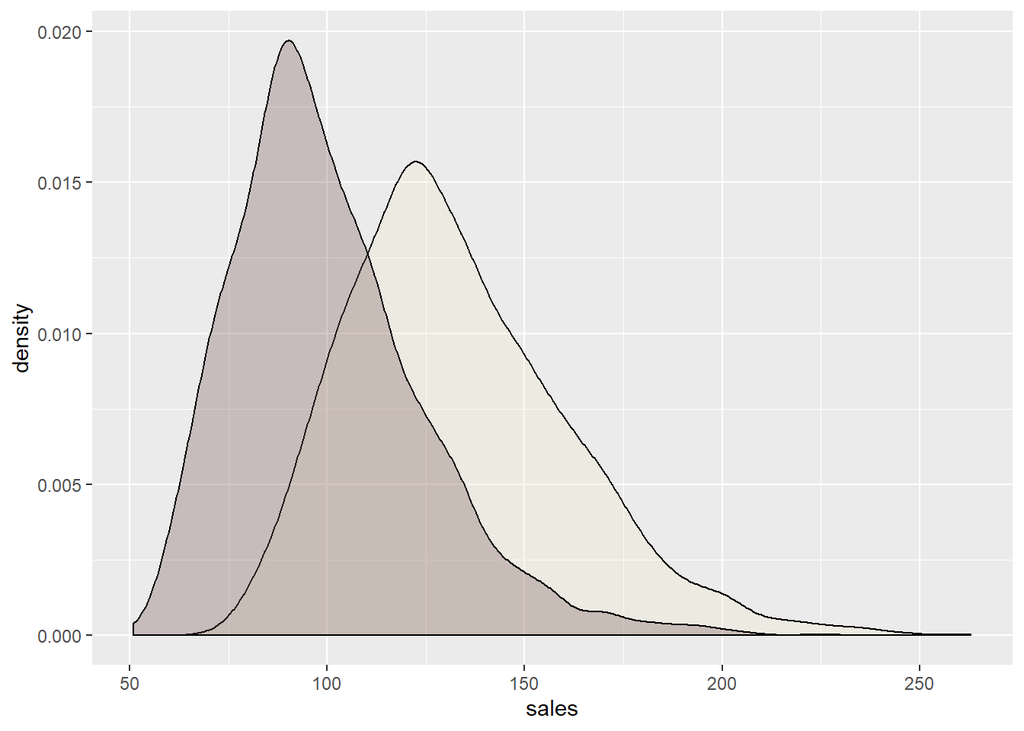

```r
ggplot(data = df) +
 geom_density(mapping = aes(x = p1sales), fill='#f1e8ca',
alpha=0.3) +
 geom_density(aes(x=p2sales), fill = '#745151', alpha=0.3) + xlab('sales')
```

### Boxplot

While histogram is a good way to show the distribution of one continuous variable, if we want to compare several distributions, it may become tricky. Densities are good, if there are not too many either. We could overlay several histograms, but if the scale between two histograms vary a lot, it is difficult to analyze. A better approach would be to use boxplots:

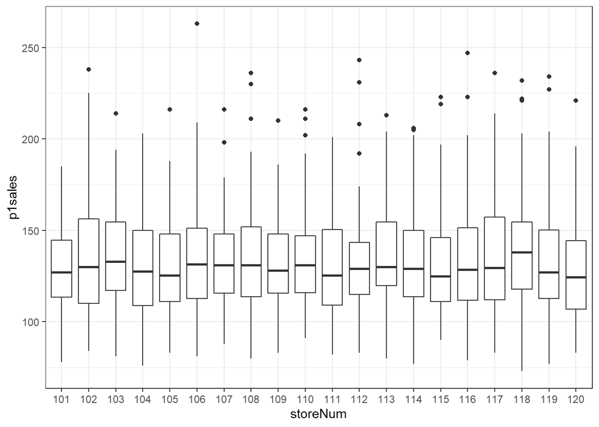

```r
ggplot(data = df, mapping = aes(x = as.factor(storeNum), y = p1sales)) + geom_boxplot() + theme_bw() + xlab("storeNum")
```

Boxplots help to quickly grasp the information about several distributions and compare it.

Try to change geom_boxplot to geom_violin. Use help to check (type ?geom_violin).

### Line chart

Line charts are often the easiest to understand :). Usually, the most common way is to use it for time-series, e.g. we want to observe a behavior over time.

Often line charts are “misused”. Look at the following graph and explain what is wrong with it:

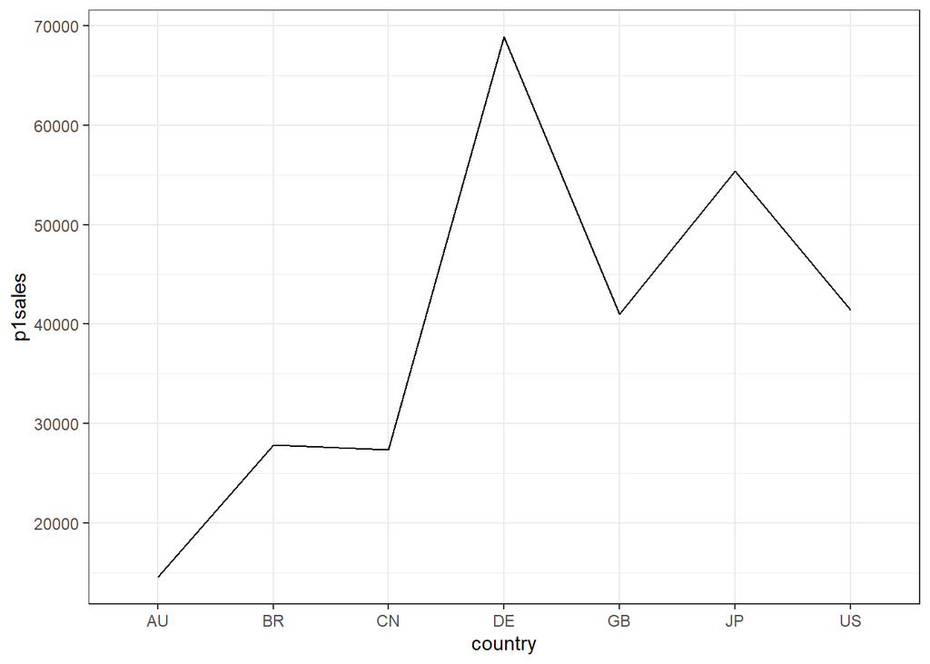

```r
df %>%
 group_by(country) %>%
 summarise(p1sales=sum(p1sales)) %>%
 ggplot(aes(x=country, y=p1sales, group=1)) + geom_line() +
theme_bw()
```

### Scatter plot. Correlation

The relationship between two variables can be expressed with the correlation coefficient. However, it only shows whether there is a linear relationship.

Make a scatterplot using product 1 and product 2 sales data. What patterns do you observe?

From graph alone it might be hard to define relationship between variable, so we can use cor() functon to have more determination:

```r
cor(df$p1sales, df$p2sales)
```

```
## [1] -0.5584222
```

The sign in correlation means in what way first feature affects second (+ for increases; - for decreses).

## Melting/Casting

There is a particular concept of long and wide data formats, as we discussed during the lecture. For example, when we made plots of two density plots for product 1 and product 2, it was not the optimal way to do it. We can tidy our data.

To do so, we will need tidyr package:

```r
install.packages("tidyr")
```

```r
library("tidyr")
```

```r
gathered_df <- df %>%
 gather(p1sales, p2sales, key = "product", value = "sales")
head(gathered_df)
```

```
##   storeNum Year Week p1price p2price p1prom p2prom country product sales
## 1      101    1    1    2.29    2.29      0      0      US p1sales   127
## 2      101    1    2    2.49    2.49      0      0      US p1sales   137
## 3      101    1    3    2.99    2.99      1      0      US p1sales   156
## 4      101    1    4    2.99    3.19      0      0      US p1sales   117
## 5      101    1    5    2.49    2.59      0      1      US p1sales   138
## 6      101    1    6    2.79    2.49      0      0      US p1sales   115
```

Now we can build the plot with densities in more natural way:

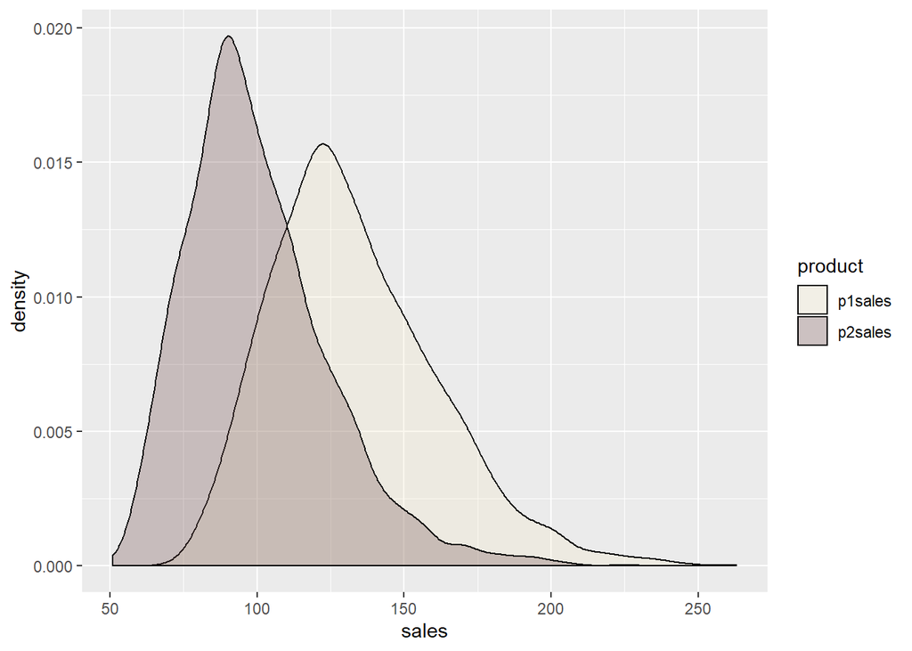

```r
ggplot(data = gathered_df) +
 geom_density(mapping = aes(x = sales, fill=product),
alpha=0.3) +
 scale_fill_manual(values = c('#f1e8ca', '#745151'))
```

## Heatmap

A heat map (or heatmap) is a graphical representation of data where the individual values contained in a matrix are represented as colors. It is really useful to display a general view of numerical data, not to extract specific data point.

In our example, we will add one more column that will display the quality of the shop:

```r
set.seed(13)
df <- cbind(df, quality = sample(as.factor(c("low", "medium", "high")), nrow(df), replace = TRUE))
```

Now we can build the heatmap:

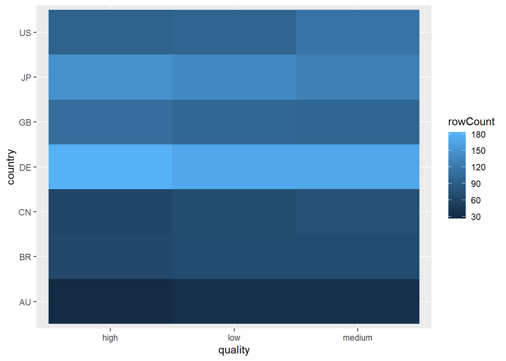

```r
df %>%
  select(quality,country) %>%
  group_by(country, quality) %>%
  summarize(rowCount= n()) %>%
  ggplot() + geom_tile(aes(x = quality, y = country, fill = rowCount))
```